# A few simple within-host models

2020-07-20 09:46:36

## A simple simulation model

- We’ll start with a very simple model, a population of entities (pathogens/immune cells/humans/animals) that grow or die.
- We’ll implement the model as a discrete time equation, given by:

\[ P_{t+dt} = P_t + dt ( g P_t - d_P P_t ) \]

- \(P_t\) are the number of pathogens in the population at current time \(t\), \(dt\) is some time step and \(P_{t+dt}\) is the number of pathogens in the future after that time step has been taken.
- The processes/mechanisms modeled are growth at rate \(g\) and death at rate \(d_P\).

## A simple simulation model

- If we started with 100 individuals (pathogens) at time t=0, had a growth rate of 12 and death rate of 2 (per some time unit, e.g. days or weeks or years), and took time steps of \(dt=1\), how many individual would we have after 1,2,3… time units?
- Why do we multiply by the time step, *dt*?

\[ P_{t+dt} = P_t + dt ( g P_t - d_P P_t ) \]

## A simple simulation model - variant 1

Original:

\[ P_{t+dt} = P_t + dt ( g P_t - d_P P_t ) \] Alternative:

\[ P_{t+dt} = P_t + dt ( g - d_P P_t ) \] What’s the difference? Is this a good model?

## A simple simulation model - variant 2

Original:

\[ P_{t+dt} = P_t + dt ( g P_t - d_P P_t ) \] Alternative:

\[ P_{t+dt} = P_t + dt ( g P_t - d_P) \]

What’s the difference? Is this a good model?

## Discrete time models

\[ P_{t+dt} = P_t + dt ( g P_t - d_P P_t ) \]

- The model above is updated in discrete time steps (to be chosen by the modeler).
- Good for systems where there is a “natural”" time step. E.g. some animals always give birth in spring or some bacteria divide at specific times.
- Used in complex individual based models for computational reasons.
- For compartmental models where we track the total populations (instead of individuals), continuous-time models are more common. They are usually formulated as ordinary differential equations (ODE).
- If the time-step becomes small, a discrete-time model approaches a continuous-time model.

## Continuous time models

Discrete:

\[ P_{t+dt} = P_t + dt ( g P_t - d_P P_t ) \] Re-write:

\[ \frac{P_{t+dt} - P_t}{dt} = g P_t - d_P P_t \]

Continuous: \[ \frac{dP}{dt} = gP - d_P P \]

- If we simulate a continuous time model, the computer uses a smart discrete time-step approximation.

## Some notation

The following are 3 equivalent ways of writing the differential equation:

\[ \begin{aligned} \frac{dP(t)}{dt} &= gP(t) - d_P P(t) \\ \frac{dP}{dt} &= gP - d_P P \\ \dot{P} &= gP - d_P P \\ \end{aligned} \] We will use the ‘dot notation’.

## Some terminology

\[ \dot{P} = gP - d_P P \]

- The left side is the instantaneous change in time of the indicated variable.
- Each term on the right side represents a (often simplified/abstracted) biological process/mechanism.
- Any positive term on the right side is an inflow and leads to an increase of the indicated variable.
- Any negative term on the right side is an outflow and leads to a decrease of the indicated variable.

## Extending the model

\[ \dot{P} = gP - d_P P \]

For different values of the parameters *g* and \(d_P\), what broad types of dynamics/outcomes can we get from this model?

## Extending the model

\[ \dot{P} = gP - d_P P \]

How can we extend the model to get growth that levels off as we reach some high level of *P*?

## Model with saturating growth

\[ \dot{P} = gP(1-\frac{P}{P_{max}}) - d_P P \]

- We changed the birth process from exponential/unlimited growth to saturating growth. \(P_{max}\) is the level of \(P\) at which the growth term is zero.
- If \(P > P_{max}\), the growth term is negative.
- The population settles down at a level where the growth balances the decay, i.e. when \(gP(1-\frac{P}{P_{max}}) = d_P P\).

## Adding a second variable

- A single variable model is ‘boring’.
- The interesting stuff happens if we have multiple compartments/variables that interact.
- Let’s introduce a second variable.
- Let’s assume that *P* is a population of some bacteria (but could also be some animal), which gets attacked and consumed by some predator, e.g. the immune system or another animal. We’ll pick the letter *H* for the predator (any label is fine).

## Adding a second variable

\[ \begin{aligned} \dot{P} & = gP(1-\frac{P}{P_{max}}) - d_P P \ \pm \ ?\\ \dot{H} & = ? \end{aligned} \]

- The predator attacks/eats the prey. What process could we add to the *P*-equation to describe this?

## Adding a second variable

\[ \begin{aligned} \dot{P} & = gP(1-\frac{P}{P_{max}}) - d_P P - kPH\\ \dot{H} & = ? \end{aligned} \]

- The more *P* there is, the more the predator will grow, e.g. by eating *P* or by receiving growth signals.
- What term could we write down for the growth dynamics of *H*?
- Finally, *H* individuals have some life-span after which they die. How can we model this?

## Predator-prey model

The model we just built is a version of the well-studied predator-prey model from ecology. \[ \begin{aligned} \dot{P} & = g_P P(1-\frac{P}{P_{max}}) - d_P P - kPH\\ \dot{H} & = g_H P H - d_H H \end{aligned} \]

The discrete-time version of the model is: \[ \begin{aligned} P_{t+dt} & = P_t + dt(g_P P_t(1-\frac{P_t}{P_{max}}) - d_P P_t - kP_tH_t)\\ H_{t+dt} & = H_t + dt( g_H P_t H_t - d_H H_t) \end{aligned} \]

## Bacteria and immune response model

The names of the variables and parameters are arbitrary. If we think of bacteria and the immune response, we might name them *B* and *I* instead.

\[ \begin{aligned} \dot{B} & = g B(1-\frac{B}{B_{max}}) - d_B B - kBI\\ \dot{I} & = r BI - d_I I \end{aligned} \] \[ \begin{aligned} B_{t+dt} & = B_t + dt(g B_t(1-\frac{B_t}{B_{max}}) - d_B B_t - k B_t I_t)\\ I_{t+dt} & = I_t + dt( r B_t I_t - d_I I_t) \end{aligned} \]

## Graphical model representation

- It is important to go back and forth between words, diagrams, equations.
- Diagrams specify a model somewhat, but not completely. The diagram below could be implemented as ODEs or discrete time or stochastic models.

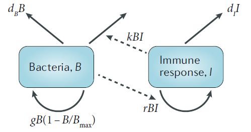

## Model exploration

- We could analyze the model behavior with ‘pencil and paper’ (or some software, e.g. Mathematica/Maxima). This only works for simple models.
- We could analyze the model behavior by simulating it.
- To simulate, we need to implement the model on a computer, specify starting (initial) conditions for all variables and values for all model parameters.

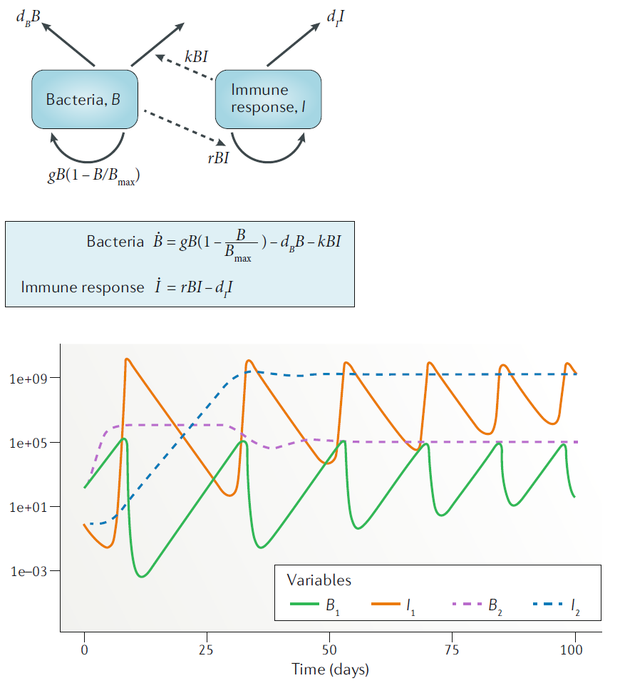

## A simple virus infection model

## A simple virus infection model

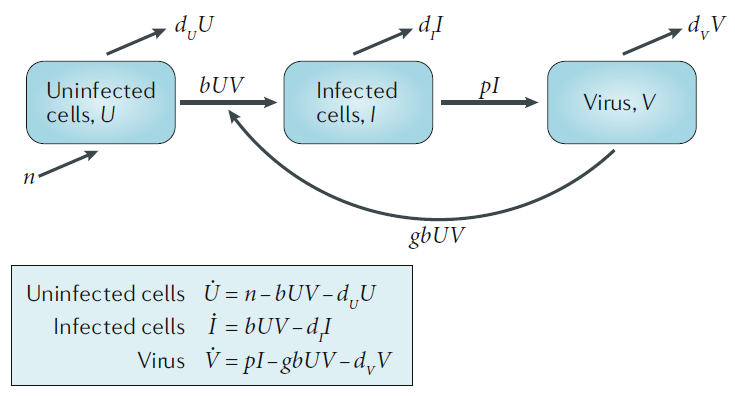

## A simple virus infection model

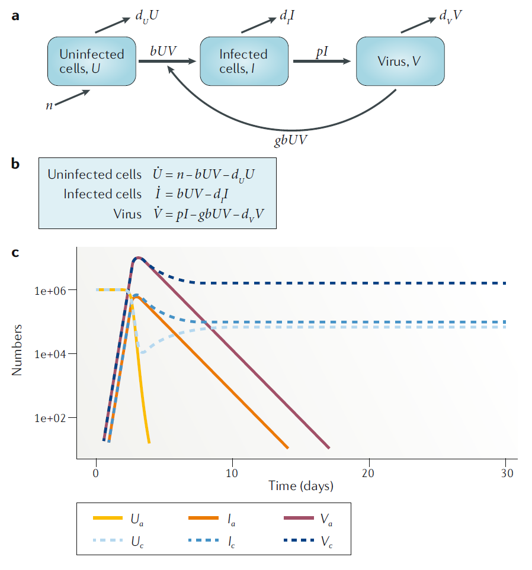

## Notation comment

- If you read the literature, you’ll see all kinds of letters used for variables and parameters. That can be confusing but unfortunately unavoidable.
- Look carefully at models and see how variables/parameters are defined. A model that looks new might in fact be one that you know, just using different notation.
- These 2 models are the same as the model we just saw!

\[ \begin{aligned} \dot{T} &= s - kT - \beta T V \\ \dot{T^*}& = \beta T V - d T^* \\ \dot{V} & = nT^* - c V - \beta g TV \\ \end{aligned} \] \[ \begin{aligned} \dot{x} & = \lambda - dx - \beta x v \\ \dot{y} & = \beta x v - a y \\ \dot{v} & = \kappa y - u v - \beta g xv \\ \end{aligned} \]

## A larger virus infection model

## Virus and Immune Response Model

- The immune response is incredibly complex, we still don’t know how to model it in much detail.
- We can nevertheless build and explore models that are a (hopefully) good balance between realism and abstraction.
- Let’s look at a virus model that contains uninfected cells (**U**), infected cells (**I**), virus (**V**), an innate immune response (**F**), CD8 T-cells (**T**), B-cells (**B**) and Antibodies (**A**).

## Model Diagram

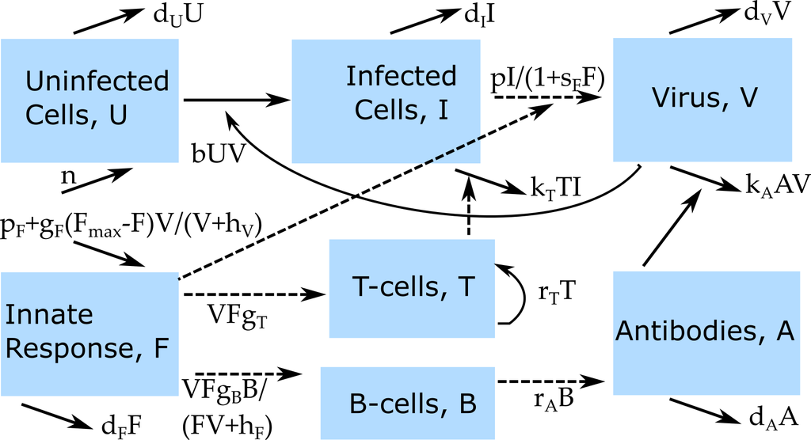

## Model Equations

\[ \begin{aligned} \dot U &= n - d_U U - bUV\\ \dot I &= bUV - d_I I - k_T T I\\ \dot V &= \frac{pI}{1+s_F F} - d_V V - b UV - k_A AV \\ \dot F &= p_F - d_F F + \frac{V}{V+ h_V}g_F(F_{max}-F) \\ \dot T &= F V g_T + r_T T\\ \dot B & = \frac{F V}{F V + h_F} g_B B \\ \dot A & = r_A B - d_A A - k_A A V \end{aligned} \]

## Learn more

DSAIRM package:

- *Basic Bacteria Model* app.
- *Basic Virus Model* app.
- *Virus and Immune Response* app.